# Expected Move Butterflies

## Background

Each week the the “expected move” can be calculated using implied volatility from prices of the options market. The S and P 500 index tends to stay within its expected move roughly 68 percent of the time. The strategy analyzed here involves buying butterflies at the beginning of each week at the edges of the expected move and selling them at the end of the week, since the edges of the expected move tend to act as magnets and it’s very common to see markets pause at those levels.

I analyzed the past four years worth of weekly expected moves, from 2015 to 2019, to answer the question: What is more profitable: to place butterflies each week on the upper end of the expected move, the lower end of the expected move, or on both the upper and the lower?

## Findings

The result of my findings is that at least during the last 4 years, there is no significant difference in profitability by changing where butterflies are placed. Additionally there was no correlation found between the level of volatility* and the amount of profitability. Because of that, a trader may as well place butterflies on both the upper and lower ends of the expected move to take advantage of both sides.

```r
pander(butterflies %>% group_by(Placement) %>% summarise(Minimum = min(Profit), Average = mean(Profit), Maximum = max(Profit)))
```

| Placement | Minimum | Average | Maximum |
| --- | --- | --- | --- |
| combined | -0.3114 | 0.05056 | 0.754 |
| lower | -0.143 | 0.02674 | 0.755 |
| upper | -0.1927 | 0.02382 | 0.801 |

*I considered weeks where the expected move was equal to or lower than 3.50 to be low volatility.

## Method

I asked the following questions and hypothesis:

1. Does the placement of the butterfly affect profitability?

Factor: `Placement` with levels $Upper$, $Lower$, and $Combined$.
$$H_0: \mu_U = \mu_L = \mu_C = \mu$$
$$H_a: \mu_i \neq \mu \ \text{for at least one}\ i\in\{1=Upper,2=Lower,3=Combined\}$$

2. Does implied volatility affect profitability?

Factor: `Volatility` with levels $High$ and $Low$.
$$H_0: \mu_H = \mu_L = \mu$$
$$H_a: \mu_i \neq \mu \ \text{for at least one}\ i\in\{1=H,2=L\}$$

3. Does the effect of Placement change according to different Volatility?

$$H_0: \text{The effect of placement is the same for both categories of volatility.}$$
$$H_a: \text{The effect of placement is not the same for both categories of volatility.}$$

$$\alpha = 0.05$$

Each row in my dataset represents a trading week where two butterflies were placed. I measured the total profit, the profit just for the upper range, and the profit just for the lower range. I then converted them to the following dataset before running the ANOVA test:

```r
datatable(butterflies)
```

|  | Placement | Profit | Volatility |
| --- | --- | --- | --- |
| 1 | combined | -0.1441 | high |
| 2 | combined | 0.6131 | low |
| 3 | combined | 0.18906 | low |
| 4 | combined | -0.1836 | low |
| 5 | combined | 0.2375 | low |
| 6 | combined | -0.178 | low |
| 7 | combined | 0.4147 | high |
| 8 | combined | -0.2 | low |
| 9 | combined | -0.2123 | low |
| 10 | combined | 0.7022 | low |

[output cut: 611 more lines]

```r
pander(summary(butterflies.aov))
```

Analysis of Variance Model

|  | Df | Sum Sq | Mean Sq | F value | Pr(>F) |
| --- | --- | --- | --- | --- | --- |
| **Placement** | 2 | 0.08907 | 0.04454 | 0.9998 | 0.3686 |
| **Volatility** | 1 | 0.02726 | 0.02726 | 0.612 | 0.4343 |
| **Placement:Volatility** | 2 | 0.01884 | 0.009422 | 0.2115 | 0.8094 |
| **Residuals** | 615 | 27.4 | 0.04455 | NA | NA |

[figure not shown]

```r
xyplot(Profit ~ as.factor(Placement), data=butterflies, type=c("p", "a"), xlab="Placment", main="Significance of placement")
```

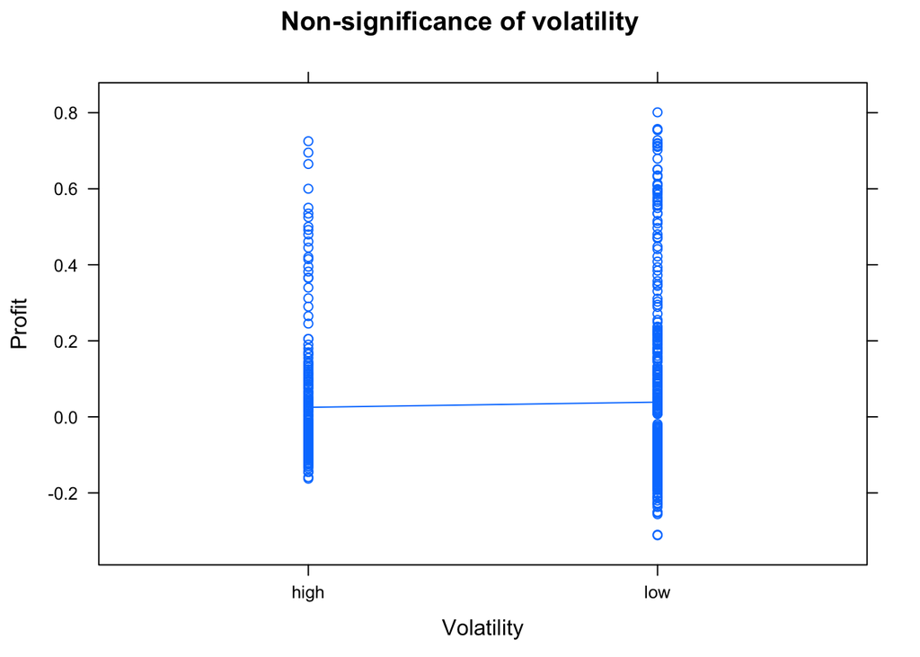

```r
xyplot(Profit ~ as.factor(Volatility), data=butterflies, type=c("p", "a"), xlab="Volatility", main="Non-significance of volatility")
```

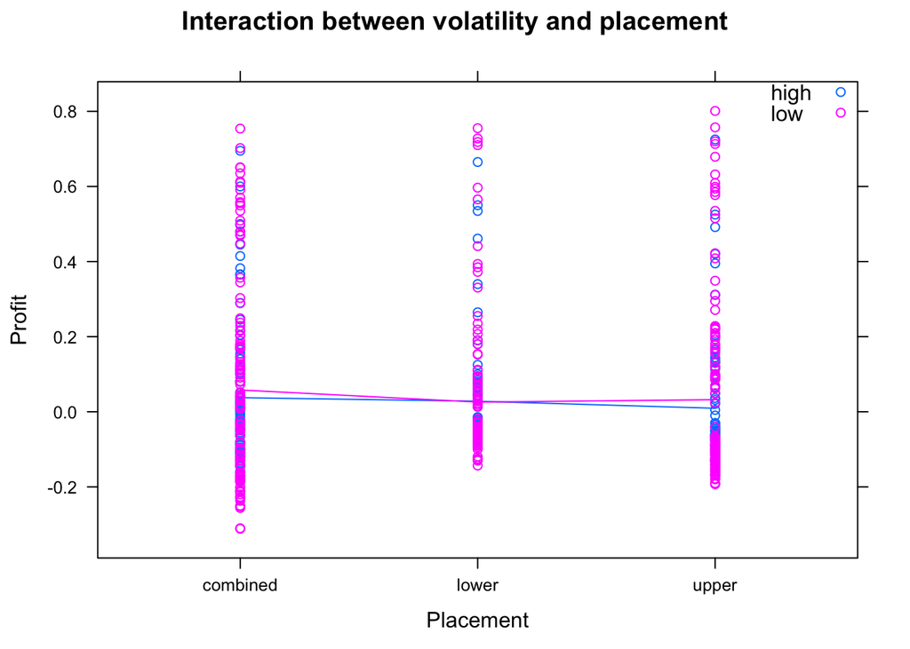

```r
xyplot(Profit ~ as.factor(Placement), data=butterflies, groups=Volatility, type=c("p", "a"), auto.key=list(corner=c(1,1)), xlab="Placement", main="Interaction between volatility and placement")
```

There is some very heavy skew that presents itself in the Q-Q plot. We do have a large enough sample size so that this isn’t too much of a concern. There may be some concerns with constant variance but I don’t believe it’s enough to discredit the analysis.

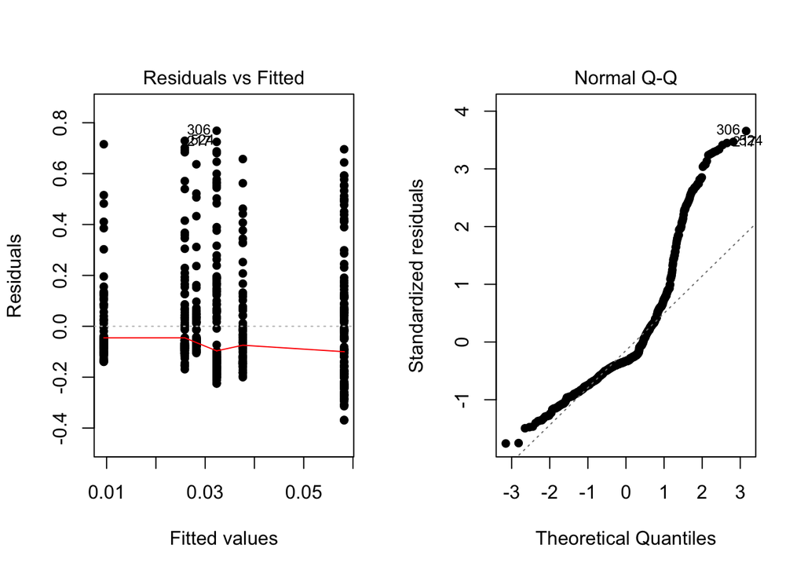

```r
par(mfrow=c(1,2))
plot(butterflies.aov, which=1:2, pch=16)
```

### Full Dataset

```r
datatable(original_butterflies)
```

|  | Year | Week | StockPrice | ExpectedMove | UpperStrike | LowerStrike | OpeningDebitUpper | ClosingDebitUpper | UpperResult | ExpiredWorthless | OpeningDebitLower | ClosingDebitLower | LowerResult | DayHit | Trend-6m) | CombinedResult |
| --- | --- | --- | --- | --- | --- | --- | --- | --- | --- | --- | --- | --- | --- | --- | --- | --- |
| 1 | 2015 | Feb 2 - Feb 6 | 199.45 | 4.664 | 204 | 195 | 0.13 | 0 | -0.13 | Yes | 0.0141 | 0 | -0.0141 | None |  | -0.1441 |
| 2 | 2015 | Feb 9 - Feb 13 | 205.55 | 3.392 | 209 | 202 | 0.024 | 0.6559 | 0.6319 | No | 0.0188 | 0 | -0.0188 | Friday |  | 0.6131 |
| 3 | 2015 | Feb 16 - Feb 20 | 209.78 | 2.671 | 212 | 207 | 0.064 | 0.33506 | 0.27106 | No | 0.082 | 0 | -0.082 | Friday |  | 0.18906 |
| 4 | 2015 | Feb 23 - Feb 27 | 211.239 | 2.708 | 214 | 209 | 0.1076 | 0 | -0.1076 | Yes | 0.076 | 0 | -0.076 | Tuesday |  | -0.1836 |
| 5 | 2015 | Mar 2 - Mar 6 | 210.66 | 2.424 | 213 | 208 | 0.156 | 0 | -0.156 | No | 0.078 | 0.4715 | 0.3935 | Friday |  | 0.2375 |
| 6 | 2015 | Mar 9 - Mar 13 | 207.5 | 3.218 | 211 | 204 | 0.131 | 0 | -0.131 | Yes | 0.047 | 0 | -0.047 | Wednesday |  | -0.178 |
| 7 | 2015 | Mar 16 - Mar 20 | 205.82 | 3.828 | 210 | 202 | 0.0603 | 0.552 | 0.4917 | No | 0.077 | 0 | -0.077 | Friday |  | 0.4147 |
| 8 | 2015 | Mar 23 - Mar 27 | 210.41 | 2.45 | 213 | 208 | 0.131 | 0 | -0.131 | Yes | 0.069 | 0 | -0.069 | Wednesday |  | -0.2 |
| 9 | 2015 | Mar 30 - Apr 3 | 205.74 | 2.981 | 209 | 203 | 0.1403 | 0 | -0.1403 | Yes | 0.072 | 0 | -0.072 | None |  | -0.2123 |
| 10 | 2015 | Apr 6 - Apr 10 | 206.435 | 3.404 | 210 | 203 | 0.148 | 0.9052 | 0.7572 | No | 0.055 | 0 | -0.055 | Friday |  | 0.7022 |

[output cut: 197 more lines]